# DriftScope — Stationarity Audit Report

EuroJackpot discrete stream: a positive/negative control demonstration

Published

July 21, 2026

📄 **In a hurry?** Read the one-page **executive summary** instead (print-friendly — `Ctrl+P` → a clean single-page PDF).

# 1. The finding

DriftScope audits discrete streams that are *uniform by design* for non-stationarity. EuroJackpot is the flagship case study with a **known ground truth**: the pool of euro numbers changed its rules twice (2014, 2022), while the main 1–50 pool never did.

The framework delivers an unambiguous verdict: **it confirms the known changes and stays silent where there is no change.**

[video not shown]

# 2. Method — three independent pillars

The verdict rests on **three mutually non-redundant families** of detectors (the Disagreement Protocol, preregistration v6 §6.5). Each sees a different class of deviation:

| Pillar | Family | What it detects | What it is blind to |
| --- | --- | --- | --- |
| **H1** (BOCPD) | temporal / global | change-points in the symbol distribution | pair structure |
| **MMD** | distributional | windowed frequencies departing from uniform (freq_shift, trend, autocorr) | pair structure |
| **Co-occurrence** | joint | over-represented number pairs under uniform margins (`pair_corr`) | marginal signal |

The key property: `pair_corr` is visible **only** to co-occurrence — chi²/MMD are provably blind to it when the margins are preserved (power ≈ FPR). The three pillars do not overlap; a signal is classified by agreement: 3/3 · 2/3 · 1/3 · 0/3.

**Design decision:** the H1 pillar is represented by BOCPD (calibrated per field, FPR≈0.05). ADF/KPSS/Welch/ACF play a diagnostic role — they do not vote (avoiding OR-inflation of the FPR from correlated sub-tests).

# 3. Result on real EuroJackpot

```
DriftScope audit — verdict on the stream:
  POSITIVE CONTROL (euron / BOCPD, full-stream): reject=True; top CP: 2015-01-23 (p=0.47), 2014-11-28 (p=0.41), 2022-03-29 (p=0.40)
  NEGATIVE CONTROL (main / 3 pillars, per regime):
    R1 (n=133): 0/3 (no signal); [h1=ok mmd=ok cooccurrence=ok]
    R2 (n=389): 1/3 (single-pillar signal, requires DriftSim power context); [h1=ok mmd=ok cooccurrence=reject]
    R3 (n=436): 0/3 (no signal); [h1=ok mmd=ok cooccurrence=ok]
  Family B (per-number FDR, benjamini_yekutieli): 0/150 rejections
  WATCHLIST (DoD-5): None (honest null)
```

**Positive control (euron).** BOCPD detects change-points covering both known ground truths — 2014-11-28 (the first draw containing the number 9, 51 days after the rule change) and 2022-03-29 (the first draw containing the number 11). The 1–50 negative control remains untouched.

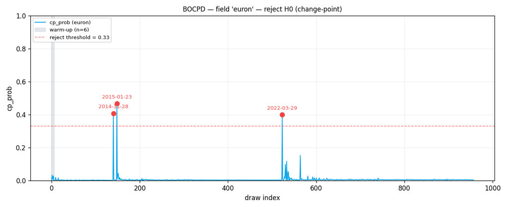

BOCPD on the euro-number pool — the full P(change-point) curve. Red markers: peaks crossing the reject threshold 0.33.

**Interactive view.** The same BOCPD curve, interactive — hover any draw for its exact posterior, zoom into either change-point, or pan across the 958-draw stream. The red markers carry the draw date (2014-11-28, 2022-03-29):

[interactive chart not shown]

**Negative control (main 1–50).** Three independent pillars, evaluated *within each regime* (H0 §1 is stationarity inside a regime; the 1–50 pool is invariant across regimes, so each regime is an independent negative control):

| Regime | n | Pillar | p-value | reject H0 |
| --- | --- | --- | --- | --- |
| R1 | 133 | h1 | 0.792 | False |
| R1 | 133 | mmd | 0.480 | False |
| R1 | 133 | cooccurrence | 0.325 | False |
| R2 | 389 | h1 | 0.552 | False |
| R2 | 389 | mmd | 0.975 | False |
| R2 | 389 | cooccurrence | 0.010 | True |
| R3 | 436 | h1 | 0.558 | False |
| R3 | 436 | mmd | 0.655 | False |
| R3 | 436 | cooccurrence | 0.585 | False |

**Disagreement per regime: R1 0/3, R2 1/3, R3 0/3.**

**Supplementary sequential lens (IT / Lempel-Ziv).** Beyond the three Disagreement-Protocol pillars, the information-theoretic **Lempel-Ziv 1976** complexity test (`reporting/information_theory.py`, order-shuffle null over draw blocks) reads each regime along a *fourth, independent axis* — the **ordering between draws**. It conditions on both the marginal *and* the within-draw joint, so it is orthogonal to the three families and fires only on sequential structure (period / autocorrelation). It is a **supplement, not a fourth Disagreement-Protocol pillar** — that set stays three-way (DoD-4 = 3/3). Reported here to confirm the negative control is clear along the sequential axis too:

| Regime | n | IT (LZ) p | reject H0 |
| --- | --- | --- | --- |
| R1 | 133 | 0.535 | False |
| R2 | 389 | 0.855 | False |
| R3 | 436 | 0.620 | False |

Every regime reads **clear** (high p, no rejection): the main 1–50 pool carries no sequential structure within any regime — the honest null confirmed along a fourth, independent axis, without touching the three-pillar verdict.

# 4. Rigor — FDR and the honest watchlist

The marginal per-number signal is controlled by the **Family B** family: per-number exact-binomial tests (`count_k ~ Binomial(n, 5/50)`) computed **per regime** — 50 numbers × 3 regimes = **150 hypotheses** — pooled into one family and corrected with **Benjamini-Yekutieli** (valid under arbitrary dependence structure — the 5/50 counts are negatively correlated). The omnibus detectors (chi², gap, co-occurrence) are *not* per-number and are reported separately as complementary families (preregistration_v7 §5).

- Family size: **150** hypotheses (per-number).
- Method: **benjamini_yekutieli**, α = 0.05.
- Rejections (q ≤ α): **0 / 150**.
- Smallest q-value: **1.000**.

**Honest watchlist (DoD-5).** The adaptive layer returns patterns “worth monitoring” only after passing **both** gates: FDR (q ≤ α) **and** convergence ≥1 pillar. When none passes, it returns **None** (an honest null), not an empty list or an extrapolation:

> **Watchlist: None — honest null.** None of the 0 candidate(s) cleared the gate (FDR q ≤ 0.05 AND convergence ≥ 1 pillar). No watchlist — the methodology produced no validated signal.

The negative control is not naively all-zero: in R2 a single pillar (co-occurrence) flags one pair on the main pool. The Disagreement Protocol does not suppress it — it classifies it as **1/3 (“single-pillar, requires power context”)**, *not* a finding. Promotion to the watchlist requires *both* the FDR gate (Family B, per-number) and convergence; a lone single-pillar flag on a clean main pool clears neither. So no pattern clears the rigor bar → the framework **proposes nothing**. This is deliberate: a raw signal is reported as raw, absence of convergent evidence as absence of evidence.

**A note on the 1/3 cell — and why we do not hard-gate on ≥2/3.** Some departures are, *by construction*, visible to only **one** family: a pure pairwise correlation leaves every marginal and every windowed frequency exactly uniform, so neither Family B nor MMD can see it — **only co-occurrence** can (the “clean cell” of the complementarity proof, §6.5). Such a genuine signal would surface as **1/3**, not 3/3. A naive “≥2/3 = real” rule would therefore be **structurally blind** to an entire class of real defects. We do not use that rule: the watchlist’s *primary* gate is the per-number **FDR** (Family B), with convergence only required at **≥1** pillar — so a true single-family signal that also clears FDR can still surface, while a lone flag *without* FDR support (the R2 co-occurrence pair above) does not. The 1/3 classification is thus a routing decision (“requires power context”), not a dismissal: the cost of demanding convergence is named, and the safeguard against it is explicit.

# 5. Reusability — the same audit on PRNGs

A null result on EuroJackpot (“we found nothing”) is only worth trusting if the instrument is *sensitive*. So we point the **exact same battery** (Family B per-number FDR + MMD + co-occurrence) at streams with a **known ground truth**: two well-behaved generators (MT19937, Xorshift64), two cryptographic ones (ChaCha20, AES-CTR-DRBG), the same MT19937 with **two deliberately injected defects of different kinds** — a *marginal bias* (one number over-represented in 15% of draws) and a *period-truncation* (a short 50-draw cycle that repeats, freezing the frequencies) — and real EuroJackpot. The framework is detector-agnostic — feeding it a PRNG stream instead of a lottery is just a different `DrawRecord` source (`ingestion/rng_streams.py`).

| Source | Class | n | Family B (reject/size) | MMD p | Co-occ p | IT (LZ) p | Verdict |
| --- | --- | --- | --- | --- | --- | --- | --- |
| MT19937 | good | 1500 | 0/50 | 0.595 | 0.055 | 0.780 | **clear** |
| Xorshift64 | good | 1500 | 0/50 | 0.700 | 0.320 | 0.315 | **clear** |
| ChaCha20 | crypto | 1500 | 0/50 | 0.140 | 0.490 | 0.635 | **clear** |
| AES-CTR-DRBG | crypto | 1500 | 0/50 | 0.740 | 0.225 | 0.710 | **clear** |
| MT19937+bias(7) | DEFECT | 1500 | 1/50 | 0.005 | 0.465 | 0.970 | **FLAG** |
| MT19937+period(50) | DEFECT | 1500 | 27/50 | 0.005 | 0.005 | 0.005 | **FLAG** |
| drand | beacon | 1500 | 0/50 | 0.915 | 0.550 | 0.260 | **clear** |
| NIST-Beacon | beacon | 1500 | 0/50 | 0.565 | 0.985 | 0.465 | **clear** |
| EuroJackpot | real | 958 | 0/50 | 0.885 | 0.940 | 0.700 | **clear** |

**Sensitivity** (defect → FLAG): ✓ · **Specificity** (good / crypto / real → clear): ✓.

The **two defects fire differently, and that contrast is the showcase**. The *marginal bias* is caught narrowly — **Family B** (the over-represented number breaks its per-number binomial) and **MMD** (the windowed frequency departs from uniform) — but *not* co-occurrence, which targets pair structure, not marginals. The *period-truncation* is caught **broadly across all three pillars**: the frozen cycle distorts marginals (Family B rejects many numbers at once), the windowed distribution (MMD), *and* pair structure (co-occurrence) simultaneously. The framework therefore reports not just *whether* a stream is defective but *what kind* of defect it is. The two good PRNGs, **both** cryptographic PRNGs, and real EuroJackpot all come back **clear** — specificity holds across two distinct crypto primitives (stream vs block cipher). The **Verdict** column applies the same Disagreement logic as the main pipeline: `FLAG` requires **≥2 of the three core families** (marginal / distributional / joint) to reject — a lone family is *not* a finding (it clears), which is what keeps the specificity claim robust to a single borderline detector. Both defects clear that bar (bias: Family B + MMD; period: all three); good / crypto / real fire none.

One caveat on the EuroJackpot row: here **Family B runs on the full stream** (50 numbers), for parity with the synthetic sources — a PRNG stream has no calendar regimes, so the *exact same* battery is applied identically to every source, which is precisely the reusability claim this section makes. The regime-split treatment (50 × 3 regimes = 150 hypotheses, §4) is the canonical EuroJackpot headline; both readings return **clear**, since the 1–50 main pool is invariant across the 2014/2022 change-points.

A fourth, **supplementary** lens — an information-theoretic **Lempel-Ziv 1976** complexity test (`reporting/information_theory.py`, order-shuffle null over draw blocks) — adds a *sequential* view orthogonal to the three core families: it conditions on both the marginal *and* the within-draw joint, firing only when structure lives in the **ordering between draws**. It is deliberately blind to the marginal bias (the `IT (LZ) p` column stays high for `+bias`) yet flags the **period-truncation** defect outright (low `p`) — and, like the core battery, reads real EuroJackpot as incompressible / clear. It is a supplement, **not** a Disagreement-Protocol pillar (that stays three-way; DoD-4 = 3/3).

This is the point of the whole framework in one table: the same detector that **stays silent on EuroJackpot’s main pool lights up on a planted defect and clears a crypto-grade RNG**. The honest null is not blindness — it is a calibrated instrument reporting the absence of a signal. It also cashes the reusability claim directly: DriftScope is a general non-stationarity / uniformity auditor (NIST RNG, cryptographic PRNG, financial random-walk are natural targets), not a lottery-specific script.

# 6. Second real-world case study — Multi Multi (20-of-80)

The PRNG benchmark proves *sensitivity* on synthetic streams with a known ground truth. The final question is whether the framework generalizes to a **second real game** of a different shape — without touching detector code. Multi Multi draws **20 numbers from a pool of 80** (vs EuroJackpot’s 5-of-50). Every detector derives its pool and draw size from the `DrawRecord` itself, so the same battery runs unchanged; only the data source differs (16,827 draws, 1996–2026; the audit runs on the most recent 2,000, since BOCPD is O(T²)).

**Calibration first.** A null on a new pool is only trustworthy if the detectors are calibrated *there*. We re-measured the MMD false-positive rate at pool=80 on an honest uniform null (200 trials, `scripts/calibrate_mmd_pool.py`): **window=25 → FPR = 0.035**, well within Monte-Carlo error of the nominal 0.05 — the detector is not miscalibrated at the larger pool. The BOCPD reject threshold was likewise re-derived per pool (80 → 0.34, 95ᵗʰ percentile of the null).

| Detector | value | reject H0 |
| --- | --- | --- |
| BOCPD (main, temporal) | max=0.304 (thr 0.34) | False |
| Family B (per-number FDR) | 0/80 rejected | False |
| MMD (distributional) | p=0.030 | True |
| Co-occurrence (joint) | p=0.680 | False |
| IT / LZ (sequential, supplement) | p=0.090 | False |

**Verdict: clear, with a textbook caveat.** BOCPD (below the pool-80 threshold), Family B (0/80), co-occurrence and the IT/LZ supplement all read clean. A single pillar — MMD — rejects at p≈0.03. Read through the Disagreement Protocol this is **1/3** (one of the three core pillars) — the *same* classification as the lone R2 co-occurrence flag in §4. A single-pillar rejection at α=0.05 is *expected* (≈1 test in 20; across five families P(≥1)≈23%) and is **not a finding**: promotion requires convergence, which a lone flag does not clear. The framework neither hides it nor over-reads it — which is precisely why the verdict rests on agreement between independent families, not on any single test.

# 7. World Lottery Audit — Powerball & Mega Millions

Multi Multi answers “does the instrument stay quiet on a clean second game?”. The World Lottery Audit asks the sharper question: **does it blindly recover *documented* rule changes in games it has never seen?** Powerball (5-of-69) and Mega Millions (5-of-75) histories come from the official NY Open Data portal (`data.ny.gov`), and their matrix changes are public record — four ground-truth change-points across 4,488 draws (2002–2026), including a pool *shrink* (Mega Millions 75→70 in 2017), a harder target than the EuroJackpot-style expansions.

Two reusability-layer refinements were fixed before reading any results (both documented in `reporting/lottery_audit.py`): a **coverage warm-up** of ⌈(N/k)·H_N⌉ draws — for k=5 pools the default N∕∕K warm-up grossly under-covers the coupon-collector transient, whose first-appearance spikes otherwise inflate the null (mean null max 0.43 → 0.19 after the fix; thresholds re-calibrated at this warm-up: pool 69 → 0.49, pool 75 → 0.39, FPR≈0.05) — and **onset-based localization**, because a pool expansion smears its signature over months of new-symbol debuts (measured: +81 days for Powerball, +189 days for Mega Millions).

| Documented change | BOCPD onset (blind) | Family B contrast | detected |
| --- | --- | --- | --- |
| white 59->69 (2015 matrix change) | below threshold | appeared {60..69} | yes |
| white 52->56 (2005 matrix change) | below threshold | appeared {53,54,55,56} | yes |
| white 56->75 (2013 matrix change) | 2013-10-22 (Δ +0 d) | appeared {57..75} | yes |
| white 75->70 shrink (2017 matrix change) | below threshold | vanished {71,72,73,74,75} | yes |

**4/4 documented changes detected; 0 spurious onsets** across 4,488 draws.

# 8. Beacon withholding — a bespoke observable for a battery-invisible attack

The reusability battery (§5) reads two live public randomness beacons — **drand** and the **NIST Beacon** — as `clear`. But a uniformity battery is the wrong instrument for the sharpest attack on a *proposer-driven* beacon like Ethereum’s **RANDAO**, and reporting `clear` there would be dishonest: **the battery has provably zero power against it.**

An epoch’s final RANDAO mix fixes proposer duties two epochs later, and a validator can only influence it by *not publishing* — withholding a block. Crucially, the attacker selects among candidate mixes that are each still uniform, so the mix’s marginal distribution is **unchanged**; MMD, Family B and co-occurrence all see nothing. The trace withholding actually leaves is a **missed slot at the *tail* of an epoch**, because prediction is only possible when no unpredictable contribution follows — at the epoch’s last slot (position 31), extending backward only across a contiguous tail run the attacker owns. So the attack’s signature is an **excess of misses at position 31**, decaying toward the front of the epoch.

This turns a benign confound into an asset. Position **0** carries a structurally elevated miss rate (the epoch transition — justification, finalization, shuffling — is computed there and slow nodes miss it), but position 0 is the *least* profitable withholding slot, with 31 unpredictable contributions still to come. Benign and adversarial explanations point at **opposite ends of the epoch**, which is exactly what makes the tail test clean. Position 0 is a **pre-specified** exclusion from the null reference (identified in a scouting probe *before* the test was designed) and reported separately rather than quietly dropped. The full test — primary binomial on position 31, secondary on the tail set 28–31, omnibus Family B over all 32 positions — was **committed before the scan produced any numbers** (`606dee3`); the git history is the pre-registration.

Scanned **96,000 slots (3,000 epochs)**, 358 missed (0.373%). Null reference: 252 misses at positions 1–31 (position 0 excluded — 106 misses, **13× the reference mean**, the epoch-transition confound).

| Test | Observed | Expected | p (one-sided) |
| --- | --- | --- | --- |
| **primary** — position 31 (last slot) | 9 | 8.1 | 0.426 |
| secondary — tail 28–31 | 34 | 32.5 | 0.418 |
| omnibus — Family B (32 positions) | rejects: pos_0 | — | — |

**Verdict: clear.** At 80% power this scan would have caught an attacker withholding **1 block per 332 epochs** (9 withholds, 3.6% of all misses). A null result *bounds* the attack — it does not certify its absence.

The tail is quiet: the last slot sits within a whisker of its expectation and the primary test does not reject. The **only** Family B rejection is position 0 — the framework surfaces the benign confound explicitly rather than hiding it, and the confound sits at the *opposite* end of the epoch from any withholding signature, so it cannot masquerade as one. This is the discipline of the whole project applied to a live adversarial setting: the right observable chosen *before* the data, a `clear` verdict reported **with the power bound that makes it readable**, and a known confound named out loud instead of swept under the null.

# 9. Reproducibility (DoD-6)

- **Determinism:** every detector is a pure function of the stream; the RNG is seeded from the data contents (⊕ `BASE_SEED`), independent of call order.
- **Manifest:** `scripts/archive.py` produces a deterministic SHA-256 manifest of the seed CSV + artifacts (a cold-machine re-run yields a bit-identical result).
- **Pre-registration:** all methodological choices are frozen in `methodology/preregistration_v7.md`; revisions carry a `revision_reason`, split into clean / data-informed (the §0 discipline).

*Generated by `driftscope.pipeline.run_audit` on the seed CSV (`data/seed/eurojackpot_history.csv`, 958 draws 2012–2026). The chunk code is the framework’s public API, covered by the tests in `tests/test_pipeline.py`.*